# Focusing on R Essentials

Randy Pruim  
2013-May-18

## Less Volume, More Creativity

### Less Volume, More Creativity

A lot of times you end up putting in a lot more volume, because you are teaching fundamentals and you are teaching concepts that you need to put in, but you may not necessarily use because they are building blocks for other concepts and variations that will come off of that … In the offseason you have a chance to take a step back and tailor it more specifically towards your team and towards your players.“  
Mike McCarthy, Head Coach, Green Bay Packers

[figure not shown]

### SIBKIS

Perfection is achieved, not when there is nothing more to add, but when there is nothing left to take away.  
— Antoine de Saint-Exupery

### The Most Important R Template

## **goal ( yyy ~ xxx , data = mydata )**

### The Most Important R Template

## **goal ( y ~ x , data = mydata )**

### The Most Important R Template

## **goal ( y ~ x , data = mydata , …)**

### Simpler version:

- `goal( ~ x, data = mydata )`

### Fancier version:

- `goal( y ~ x | z , data = mydata )`

### Unified version:

- `goal( formula , data = mydata )`

### The Two Questions

## **goal ( y ~ x , data = mydata )**

### What do you want R to do? (goal)

- This determines the function to use

### What must R know to do that?

- This determines the inputs to the function
- Must identify the variables and data frame

### Graphical Summaries: One Variable

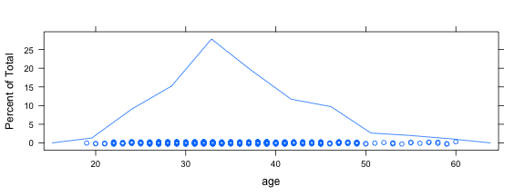

```r
freqpolygon( ~age, data=HELPrct)
```

### What is a Frequency Polygon?

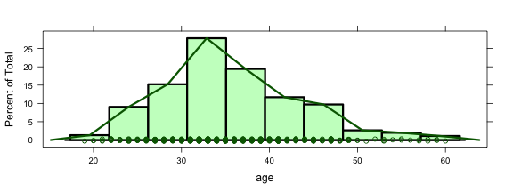

### Graphical Summaries: One Variable

```r
freqpolygon( ~age, data=HELPrct )
  histogram( ~age, data=HELPrct )
densityplot( ~age, data=HELPrct )
     bwplot( ~age, data=HELPrct )
     qqmath( ~age, data=HELPrct )
```

### Graphical Summaries: Two Variables

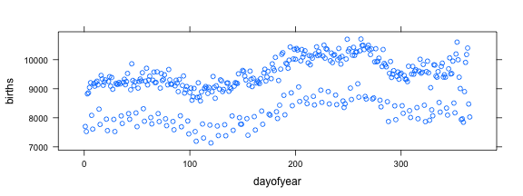

```r
xyplot( births ~ dayofyear, data=Births78)
```

### Graphical Summaries

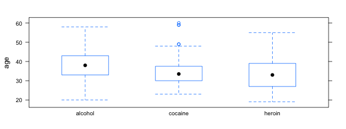

```r
bwplot( age ~ substance, data=HELPrct)
```

### Graphical Summaries

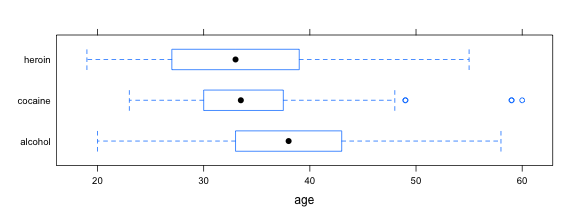

```r
bwplot( substance ~ age, data=HELPrct)
```

### The Graphics Template

## **plotname ( y ~ x , data = mydata , …)**

### One variable

- `histogram()`, `qqmath()`, `densityplot()`, `freqpolygon()`

### Two Variables

- `xyplot()`, `bwplot()`

### Your turn

**Create a plot of your own choosing.**

**Hints:**

```r
names(HELPrct)
```

- **i1** average number of drinks (standard units) consumed per day, in the past 30 days (measured at baseline)
- **i2** maximum number of drinks (standard units) consumed per day, in the past 30 days (measured at baseline)

```r
names(Utilities2)
```

## **plotname ( y ~ x , data = mydata , …)**

### groups and panels

- Add `groups = ???` to overlay plots on top of each other.
- Use `y ~ x | z` to create multipanel plots.

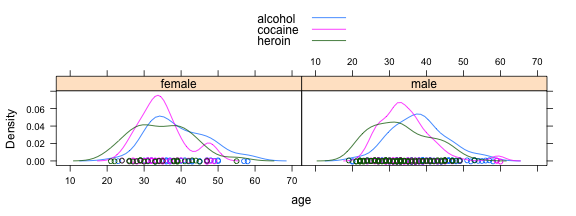

```r
densityplot( ~ age | sex, data=HELPrct,
               group=substance,
               auto.key=TRUE)
```

### Numerical Summaries: One Variable

```r
mean( ~ age, data=HELPrct )
```

```
[1] 35.65
```

```r
favstats( ~ age, data=HELPrct )
```

```
 min Q1 median Q3 max  mean   sd   n missing
  19 30     35 40  60 35.65 7.71 453       0
```

```r
tally( ~ sex, data=HELPrct)
```

```
female   male  Total
   107    346    453
```

### Numerical Summaries: Two Variables

```r
sd( age ~ substance, data=HELPrct )
```

```
alcohol cocaine  heroin
  7.652   6.693   7.986
```

### Numerical Summaries: Tables

```r
tally( sex ~ substance, data=HELPrct )
```

```
        substance
sex      alcohol cocaine heroin
  female  0.2034  0.2697 0.2419
  male    0.7966  0.7303 0.7581
  Total   1.0000  1.0000 1.0000
```

```r
tally( ~ sex + substance, data=HELPrct )
```

```
        substance
sex      alcohol cocaine heroin Total
  female      36      41     30   107
  male       141     111     94   346
  Total      177     152    124   453
```

### Your turn

**Create a numerical summary of your own choosing.**

**Hints:**

```r
names(HELPrct)
```

- **i1** average number of drinks (standard units) consumed per day, in the past 30 days (measured at baseline)
- **i2** maximum number of drinks (standard units) consumed per day, in the past 30 days (measured at baseline)

```r
names(Utilities2)
```

## **summary ( y ~ x , data = mydata , …)**

- possible summaries: `mean()`, `median()`, `min()`, `max()`, `sd()`, `var()`, `favstats()`, etc.

### Mathematical Functions

Let's define \[ f(x,y) = sin( \pi \; x) \cos(\pi \; y) \]

```r
f <- makeFun( sin(x *pi) * cos(y * pi) ~ x + y )
f(x=1/2, y=1/4)
```

```
[1] 0.7071
```

```r
f(1/2, 1/4)
```

```
[1] 0.7071
```

### Mathematical Functoins

What does \( f \) look like to R?

```r
f
```

```
function (x, y)
sin(x * pi) * cos(y * pi)
```

Could also have been defined as

```r
f <- function (x, y) { # curly braces not required
  sin(x * pi) * cos(y * pi)
}
```

### Plotting functions

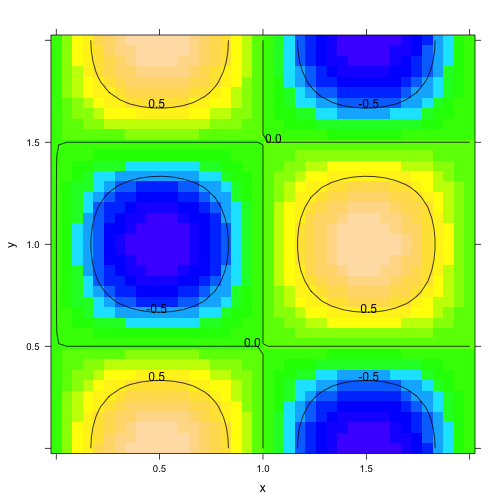

```r
plotFun( f(x,y) ~ x + y, x.lim=c(0,2), y.lim=c(0,2) )
```

### But wait, there's more

- Differentiation and Anti-differentiation

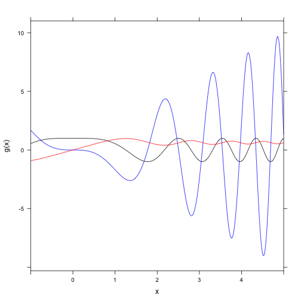

```r
f <- makeFun( cos(x^2) ~ x )
g <- D(f(x) ~ x);  G <- antiD(f(x) ~ x)
plotFun(g(x) ~ x, col = 'blue', x.lim=c(-1,5))
plotFun(f(x) ~ x, col = 'black', add=TRUE)
plotFun(G(x) ~ x, col = 'red', add=TRUE)
```

### Linear Models

- Fitting models

```r
      lm ( formula, data=mydata )
fitModel ( formula, data=mydata )
     nls ( formula, data=mydata )
```